# HW3-Olbum

Orly Olbum

Note: I saved out models for ease loading them in later and for knitting, but I left the code I ran commented out for each question.

## Question 1: LASSO with AIC

*Using the CSES data from lecture, we are going to build a predictive model to see who is likely to report that they are “close to any party” using all available information in the survey.*

*First, using glmnet, estimate a LASSO with a logistic regression with all two-way interactions included. Show the regularization path. See ?glmnet for useful information on how to specify a logistic model.*

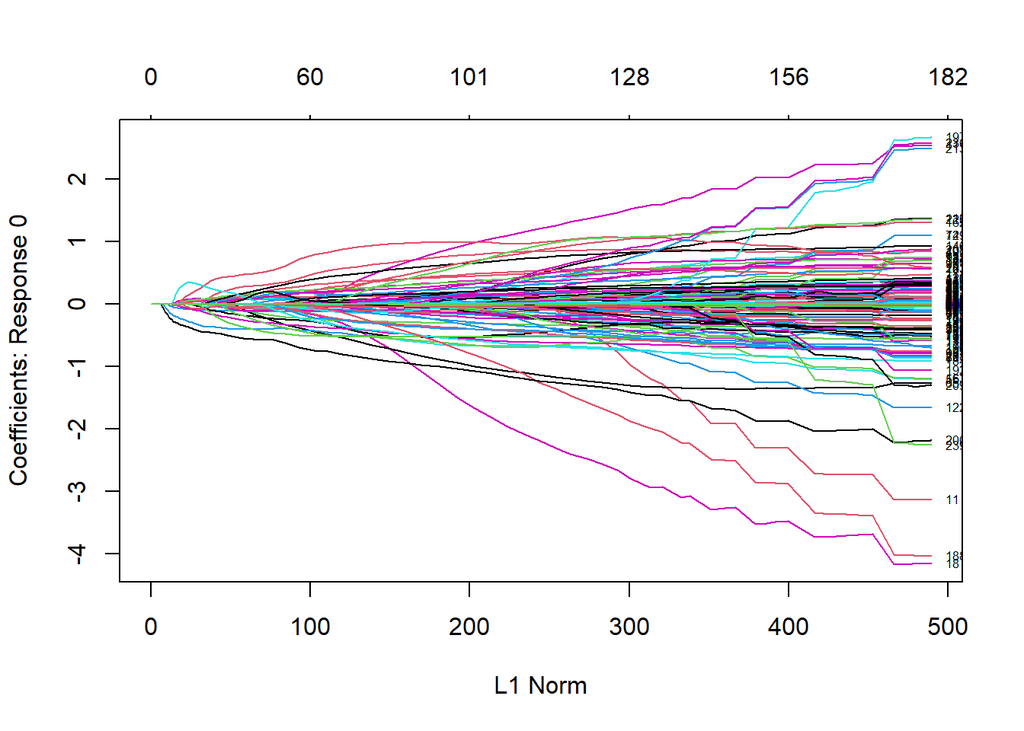

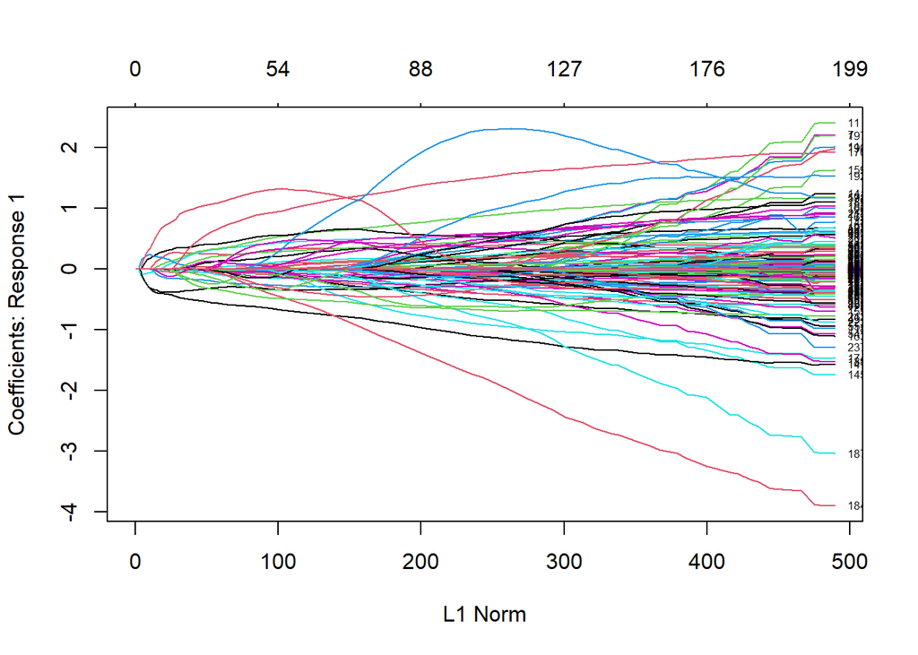

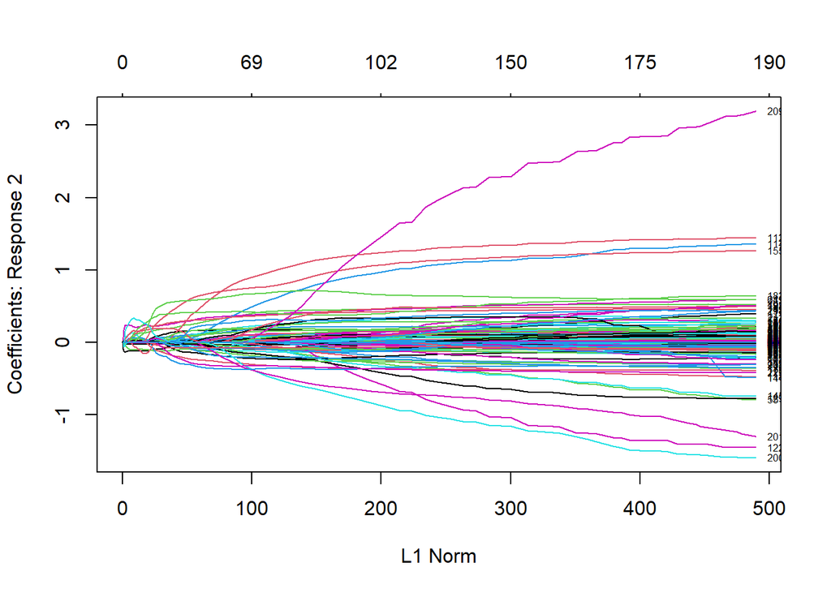

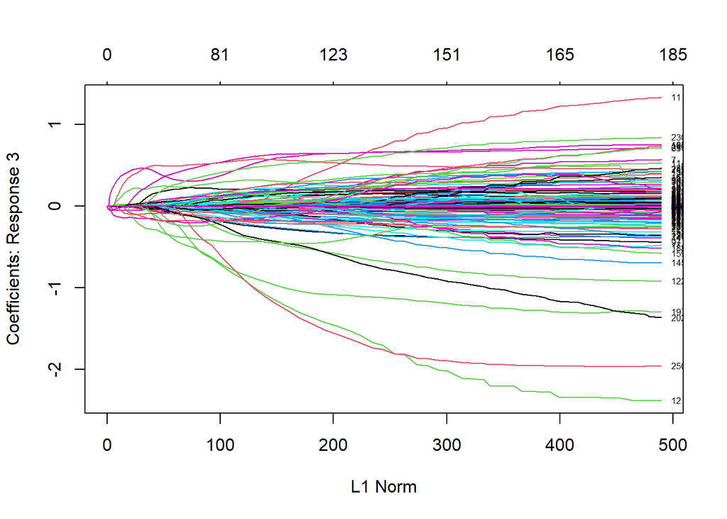

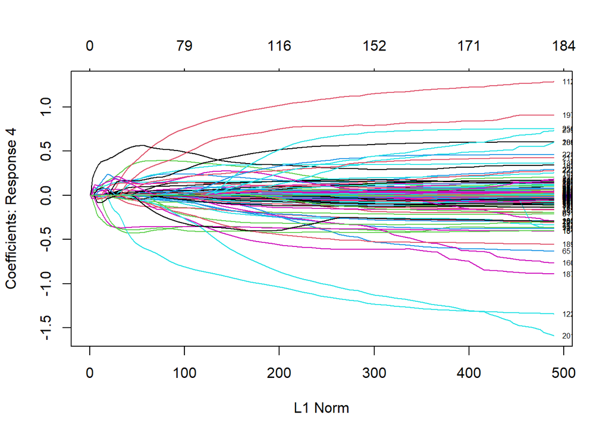

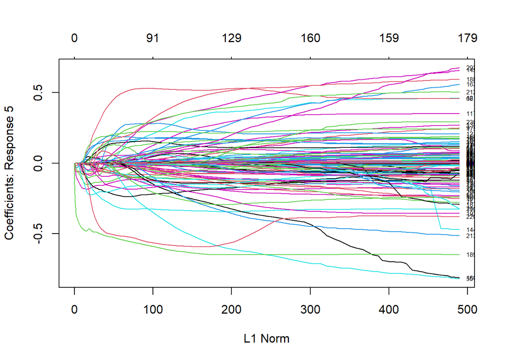

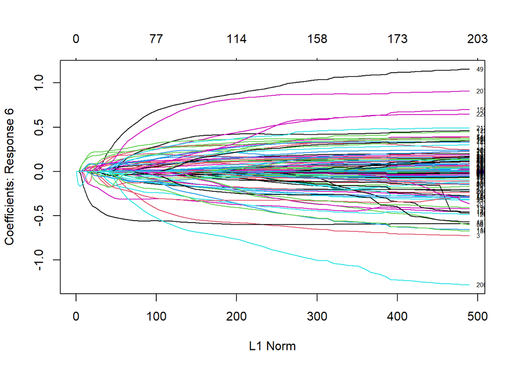

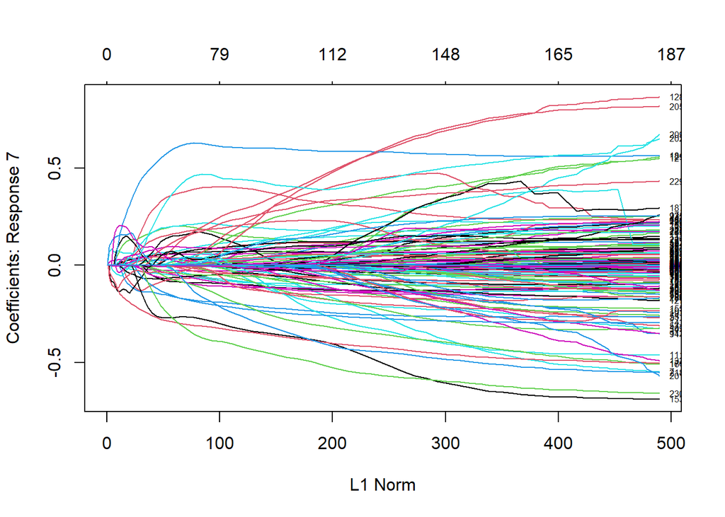

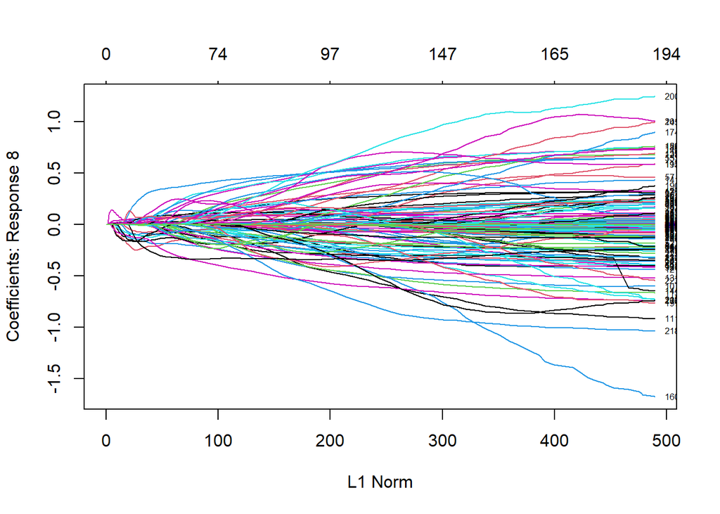

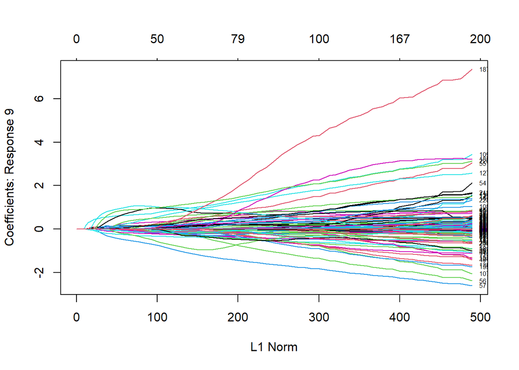

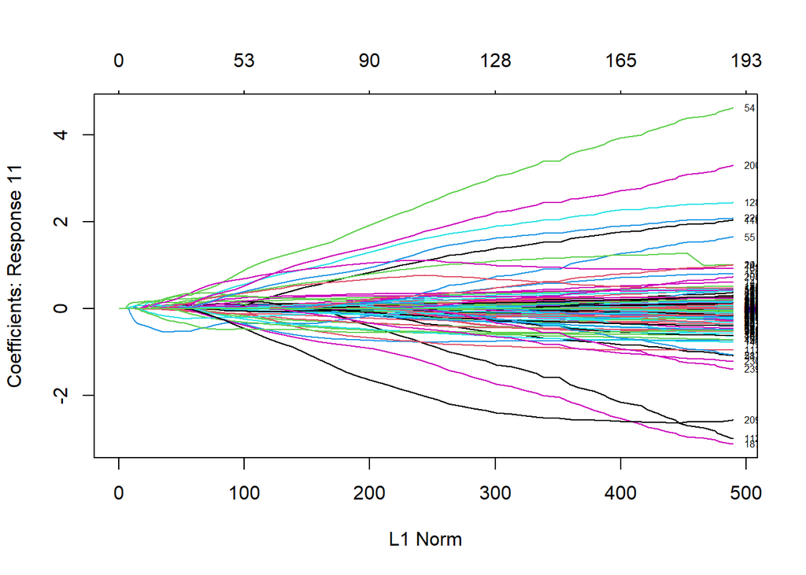

```r
# fit model
# fit_glm = glmnet(
#   x = model.matrix(self_left_right ~ . * .,
#                   data = cses),
#   y = cses$self_left_right, alpha = 1,
#   family = 'multinomial'
# )
# saveRDS(fit_glm, file = "fit_glm.rds")

# show path
plot(fit_glm, label = TRUE)
```

[output not shown]

*Second, using that fitted model, calculate the BIC for each estimated point on the curve. Use the number of non-zero parameters as the degrees of freedom. Which model would be selected?*

```r
k = fit_glm$df
n = fit_glm$nobs
tLL = fit_glm$nulldev - deviance(fit_glm)
BIC = log(n)*k - tLL
BIC = as.data.frame(BIC)
BIC$model = rownames(BIC)
BIC = BIC[,c('model', 'BIC')]
BIC
```

| model | BIC |
| --- | --- |
| 1 | -4.183676e-10 |
| 2 | 1.116145e+01 |
| 3 | 4.417556e+00 |
| 4 | -6.876176e+00 |
| 5 | -9.893035e+00 |
| 6 | -4.768908e+01 |
| 7 | -5.900601e+01 |
| 8 | -5.414566e+01 |
| 9 | -8.341131e+01 |
| 10 | -1.074637e+02 |

[output cut: 81 more lines]

```r
# want smaller (further left) BIC
selected = BIC[which(BIC$BIC == min(BIC$BIC)),]
selected
```

|  | model | BIC |
| --- | --- | --- |
| 75 | 75 | -386.5753 |

```r
# model with best BIC
coef_fit = coef(fit_glm, s = fit_glm$lambda.1se)
```

The best BIC belongs to the 75th point, where the coefficients are ‘age’, ‘female’, ‘education’, ‘income_quintile’, ‘political_interest’, ‘immigrants_good_for_economy’, and ‘immigrants_harm_culture’.

*Third, using a cross-validation approach, estimate the optimal model. Compare the selected predictions between the two approaches.*

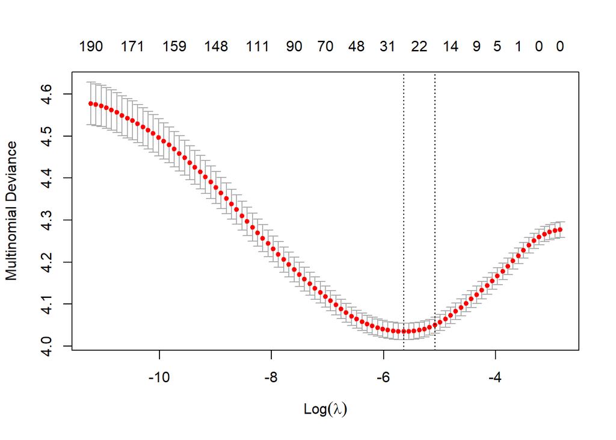

```r
# fit cv model
# fit_glm_cv = cv.glmnet(
#   x = model.matrix(self_left_right ~ . * .,
#                    data = cses),
#   y = cses$self_left_right, alpha = 1,
#   family = 'multinomial')
# saveRDS(fit_glm_cv, file = "fit_glm_cv.rds")
plot(fit_glm_cv)
```

```r
bestlambda = fit_glm_cv$lambda.1se
bestlambda
```

```
## [1] 0.006199591
```

```r
coef_fit_cv = coef(fit_glm_cv, s = 'lambda.1se')

#  now back to the glmnet
# fit_glm_update = glmnet(
#   x = model.matrix(self_left_right ~ . * .,
#                   data = cses),
#   y = cses$self_left_right, alpha = 1,
#   family = 'multinomial',
#   lambda = bestlambda
# )
# saveRDS(fit_glm_update, file = "fit_glm_update.rds")
```

Using CV, The model with the best lambda (1 se away) has coefficients ‘age’, ‘female’, ‘education’, ‘political_interest’, ‘immigrants_harm_culture’, ‘democracy_satisfaction’, and ‘close_to_any_party’.

## Question 2: Marginal Effects after LASSO

*First, estimate a model to predict turnout using cv.glmnet. Include all three-way interactions between variables for a highly complex model. You might find the trace.it and parallel options useful. Note that if you use parallel, trace.it will be less informative.*

*This model will take some time to fit; you should save it out, e.g. as an RDS, and load it in for the subsequent parts of this question (If you cannot fit in a reasonable amount of time, say 90 minutes, do all two-way interactions.).*

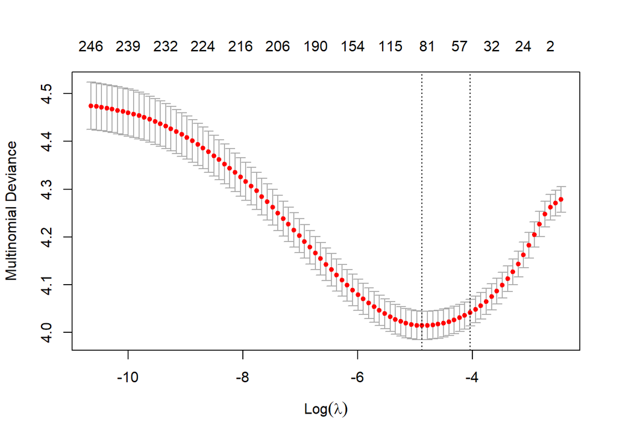

```r
# fit_glm_cv2 = cv.glmnet(
#   x = model.matrix(self_left_right ~ . * .,
#                    data = cses),
#   y = cses$self_left_right, alpha = 1,
#   family = 'multinomial', type.multinomial = 'grouped')
# saveRDS(fit_glm_cv2, 'fit_glm_cv2.rds')

plot(fit_glm_cv2)
```

```r
coef_glmnet = coef(fit_glm_cv2)
# this line is from lecture but isn't working
# names(coef_glmnet[which(coef_glmnet != 0),])
```

I did two-way interactions (ran too long).

*Second, create a well-labeled table or plot that reports the marginal effect for each variable in the original CSES dataset (e.g. self_left_right), sorted from largest to smallest. This will look similar to the plot in lecture.*

```r
set.seed(15206)
folds <- caret::createFolds(y = seq_len(nrow(cses)), k = 2)
cses_train <- cses[folds[[1]],]
cses_test <- cses[folds[[2]],]
fit_subset <- leaps::regsubsets(self_left_right ~ . * .,
                                data = cses_train, nvmax = 100, method = 'forward')
```

```
## Reordering variables and trying again:
```

```r
get_model_formula <- function(object, id, outcome){
  # get models data
  models <- summary(object)$which[id,-1]
  # Get outcome variable
  #form <- as.formula(object$call[[2]])
  #outcome <- all.vars(form)[1]
  # Get model predictors
  predictors <- names(which(models == TRUE))
  predictors <- paste(predictors, collapse = "+")
  # Build model formula
  as.formula(paste0(outcome, "~", predictors))
}

coef_glmnet2 <- coef(fit_glm_cv2)

counter_1 <- model.matrix(self_left_right ~ . * .,
                          data = cses_train %>%
                            mutate(state_of_economy = 1))
counter_0 <- model.matrix(self_left_right ~ . * .,
                          data = cses_train %>%
                            mutate(state_of_economy = -1))
# CHECK COLUMN NAMES ALIGN
# identical(colnames(counter_1), rownames(coef_glmnet2)[-1])

mfx <- as.vector(predict(fit_glm_cv2, newx = counter_1)) -
  as.vector(predict(fit_glm_cv2, newx = counter_0))
print(mean(mfx))
```

```
## [1] -2.949449e-17
```

I know the mfx output is the marginal effects but I am stuck on how to map them to the coefficients used in the model above. The output should be some sort of table that relates to the graph from lecture - the points for each coefficient, except in this case it would include the interactions as well.

*Third, briefly discuss your results.*

## Question 3: A New Toy

*Consider a different predictive tool, that we have not discussed in lecture. You often might encounter a new method and wish to apply it to your problem. We will focus on K-nearest neighbors. If you wish, although it is not required, you might read about this in ISL, e.g. Chapter 3 Section 5.*

*The short summary of the method is as follows: For each data point i, find the k-nearest data points in Euclidean space; predict a value for i using the average of the neighbor’s outcomes.*

*The key tuning parameter is k. Using train, estimate this model across a variety of k to predict self_left_right. Some sample code is included below. Note that you should not include interactions in this model as it can learn them automatically. We will come back to this point Week 9 “Extensions”.*

```r
# You'll also want to vary the tuning parameters, i.e. "k"
# See the slides/documentation for how to do this.
# fit_knn = train(self_left_right ~ .,
#                 data = cses,
#                 trControl = trainControl(method = 'cv'),
#                 method = 'knn')
# saveRDS(fit_knn, 'fit_knn.rds')
```

This model never ran for me - a few times I tried it and it and after an hour or so it crashed my computer - sorry I didn’t get to it in time to ask you for help on it.

*Next, setting aside half of the data, please create two curves: (i) plotting the k against the error in the training data and (ii) plotting k against the error in the test data. (That is, create a plot similar to that in lecture).*

*Finally, compare the plots and comment on what you find.*

Unfortunately wasn’t able to run the training model, but if I had there should be a plot here comparing the errors from training data against k along with a plot comparing the test data against k.

## Question 4: Hierarchical Models

- *Load the CCES data from 2020.*
  - *Following the recoding procedures https://bookdown.org/jl5522/MRP-case-studies/downloadingand-processing-data.html#CCES.*
  - *Note the abortion question is CC20_332a for the 2020 CCES.*

```r
# Note that the FIPS codes include the district of Columbia and US territories which
# are not considered in this study, creating some gaps in the numbering system.
state_ab <- datasets::state.abb
state_fips <- c(1,2,4,5,6,8,9,10,12,13,15,16,17,18,19,20,21,22,23,24,25,26,27,28,29,30,
                31,32,33,34,35,36,37,38,39,40,41,42,44,45,46,47,48,49,50,51,53,54,55,56)
recode_fips <- function(column) {
    factor(column, levels = state_fips, labels = state_ab)
}

# Recode CCES
clean_cces <- function(df, remove_nas = TRUE){

  ## Abortion -- dichotomous (0 - Oppose / 1 - Support)
  df$abortion <- abs(df$CC18_321d-2)

  ## State -- factor
  df$state <- recode_fips(df$inputstate)

  ## Gender -- dichotomous (coded as -0.5 Female, +0.5 Male)
  df$male <- abs(df$gender-2)-0.5

  ## ethnicity -- factor
  df$eth <- factor(df$race,
                   levels = 1:8,
                   labels = c("White", "Black", "Hispanic", "Asian", "Native American",
                              "Mixed", "Other", "Middle Eastern"))
  df$eth <- fct_collapse(df$eth, "Other" = c("Asian", "Other", "Middle Eastern",
                                             "Mixed", "Native American"))

  ## Age -- cut into factor
  df$age <- 2018 - df$birthyr
  df$age <- cut(as.integer(df$age), breaks = c(0, 29, 39, 49, 59, 69, 120),
                labels = c("18-29","30-39","40-49","50-59","60-69","70+"),
                ordered_result = TRUE)

  ## Education -- factor
  df$educ <- factor(as.integer(df$educ),
                    levels = 1:6,
                    labels = c("No HS", "HS", "Some college", "Associates",
                               "4-Year College", "Post-grad"), ordered = TRUE)
  df$educ <- fct_collapse(df$educ, "Some college" = c("Some college", "Associates"))

  # Filter out unnecessary columns and remove NAs
  df <- df %>% select(abortion, state, eth, male, age, educ)
  if (remove_nas){
    df <- df %>% drop_na()
  }

  return(df)
}

cces_clean = clean_cces(cces_all)
```

- *Proceed as follows*
  - *Create variables that are the interaction between each pair of demographic categories, e.g. age.eth.*

```r
cces_clean$educ_factor = unclass(cces_clean$educ)
cces_clean$eth_factor = unclass(cces_clean$eth)
cces_clean$age_factor = unclass(cces_clean$age)

cces_clean$age.educ = cces_clean$age_factor * cces_clean$educ_factor
cces_clean$age.eth = cces_clean$age_factor * cces_clean$eth_factor
cces_clean$eth.educ = cces_clean$eth_factor * cces_clean$educ_factor
```

- *Fit the following two hierarchical models using glmer:*

```r
# Model 1 formula
mod1 = abortion ~ (1 | state) + (1 | age) + (1 | eth) + (1 | educ)

# fit_glmer1 = glmer(mod1, data = cces_clean,
#              family = binomial())
# saveRDS(fit_glmer1, 'fit_glmer1.rds')
summary(fit_glmer1)
```

```
## Generalized linear mixed model fit by maximum likelihood (Laplace
##   Approximation) [glmerMod]
##  Family: binomial  ( logit )
## Formula: abortion ~ (1 | state) + (1 | age) + (1 | eth) + (1 | educ)
##    Data: cces_clean
##
##      AIC      BIC   logLik deviance df.resid
##  79721.2  79766.2 -39855.6  79711.2    59805
##
## Scaled residuals:
##     Min      1Q  Median      3Q     Max
## -1.6872 -0.8724 -0.6588  1.0396  2.3577
##
## Random effects:
##  Groups Name        Variance Std.Dev.
##  state  (Intercept) 0.09149  0.3025
##  age    (Intercept) 0.04404  0.2098
##  educ   (Intercept) 0.04772  0.2184
##  eth    (Intercept) 0.06069  0.2463
## Number of obs: 59810, groups:  state, 50; age, 6; educ, 5; eth, 4
##
## Fixed effects:
##             Estimate Std. Error z value Pr(>|z|)
## (Intercept)  -0.3613     0.1840  -1.963   0.0496 *
## ---
## Signif. codes:  0 '***' 0.001 '**' 0.01 '*' 0.05 '.' 0.1 ' ' 1
```

```r
# Model 2 formula
mod2 = abortion ~ (1 | state) + (1 | age) + (1 | eth) + (1 | educ) +
  (1 | age.educ) + (1 | age.eth) + (1 | eth.educ)
# fit_glmer2 = glmer(mod2, data = cces_clean,
#              family = binomial())
# saveRDS(fit_glmer2, 'fit_glmer2.rds')
summary(fit_glmer2)
```

```
## Generalized linear mixed model fit by maximum likelihood (Laplace
##   Approximation) [glmerMod]
##  Family: binomial  ( logit )
## Formula: abortion ~ (1 | state) + (1 | age) + (1 | eth) + (1 | educ) +
##     (1 | age.educ) + (1 | age.eth) + (1 | eth.educ)
##    Data: cces_clean
##
##      AIC      BIC   logLik deviance df.resid
##  79658.4  79730.4 -39821.2  79642.4    59802
##
## Scaled residuals:
##     Min      1Q  Median      3Q     Max
## -1.6263 -0.8727 -0.6483  1.0366  2.3325
##
## Random effects:
##  Groups   Name        Variance Std.Dev.
##  state    (Intercept) 0.091115 0.30185
##  age.educ (Intercept) 0.002636 0.05135
##  age.eth  (Intercept) 0.051940 0.22790
##  eth.educ (Intercept) 0.002642 0.05140
##  age      (Intercept) 0.037852 0.19456
##  educ     (Intercept) 0.041707 0.20422
##  eth      (Intercept) 0.036274 0.19046
## Number of obs: 59810, groups:
## state, 50; age.educ, 17; age.eth, 15; eth.educ, 13; age, 6; educ, 5; eth, 4
##
## Fixed effects:
##             Estimate Std. Error z value Pr(>|z|)
## (Intercept)  -0.3393     0.1727  -1.965   0.0494 *
## ---
## Signif. codes:  0 '***' 0.001 '**' 0.01 '*' 0.05 '.' 0.1 ' ' 1
```

*Next, decide which model is preferable using a data driven approach (e.g. perform cross-validation).*

## Question 5: MRP from Start to Finish

- *Using the CCES from 2020, perform MRP from “start to finish”. We want to get state-level estimates for a particular question.*
- *You should follow the following steps. This will follow what we covered in lecture.*
  - *Pick one (binary) question to perform MRP on. Pick one that is substantively interesting to you!*
  - *Using the ACS Microdata, choose three or four variables to perform MRP on. At least one should be different from what we did in class. You may use the variables we considered in class for partial credit.*
    - *You can see how to download the data from https://bookdown.org/jl5522/MRP-case-studies/downloading-and-processing-data.html.*
  - *Proceed as we did in class:*
    - *recode the CCES to align with those ACS categories.*
    - *Fit the hierarchical model on the CCES with a random intercept for state*
    - *Post-stratify using the ACS data*
  - *Show your results in a plot with the county estimates ranging from smallest to largest.*

```r
# Get our "fake" ground truth
cces_truth = cces_clean %>%
  group_by(state) %>%
  summarize(abortion = mean(abortion))

# Get our "sample"
cces_sample <- cces_clean %>%
  slice_sample(n = 2000)

presvote <- presvote %>% filter(year == 2020) %>%
  filter(party_simplified %in% c('DEMOCRAT', 'REPUBLICAN')) %>%
  group_by(state_po) %>%
  mutate(pr_rep = candidatevotes/sum(candidatevotes)) %>%
  filter(party_simplified == 'REPUBLICAN') %>%
  select(state = state_po, pr_rep)
cces_sample <- left_join(cces_sample, presvote, by = 'state')

# fit model
fit_MRP <- glmer(abortion ~ pr_rep + (1 | state) + (1 | age) +
                   (1 | eth) + (1 | male) + (1 | educ),
                 data = cces_sample, family = binomial())

fit_MRP_2 <- glmer(abortion ~ (1 | state) + (1 | age) + (1 | eth) +
                     (1 | male) + (1 | educ),
                   data = cces_sample, family = binomial())

summary(fit_MRP)
```

```
## Generalized linear mixed model fit by maximum likelihood (Laplace
##   Approximation) [glmerMod]
##  Family: binomial  ( logit )
## Formula: abortion ~ pr_rep + (1 | state) + (1 | age) + (1 | eth) + (1 |
##     male) + (1 | educ)
##    Data: cces_sample
##
##      AIC      BIC   logLik deviance df.resid
##   2626.5   2665.7  -1306.3   2612.5     1993
##
## Scaled residuals:
##     Min      1Q  Median      3Q     Max
## -1.7242 -0.8251 -0.5965  1.0042  3.0751
##
## Random effects:
##  Groups Name        Variance Std.Dev.
##  state  (Intercept) 0.05830  0.2415
##  age    (Intercept) 0.09185  0.3031
##  educ   (Intercept) 0.08538  0.2922
##  eth    (Intercept) 0.19666  0.4435
##  male   (Intercept) 0.02362  0.1537
## Number of obs: 2000, groups:  state, 49; age, 6; educ, 5; eth, 4; male, 2
##
## Fixed effects:
##             Estimate Std. Error z value Pr(>|z|)
## (Intercept)  -1.7440     0.4713  -3.700 0.000215 ***
## pr_rep        2.5426     0.7041   3.611 0.000305 ***
## ---
## Signif. codes:  0 '***' 0.001 '**' 0.01 '*' 0.05 '.' 0.1 ' ' 1
##
## Correlation of Fixed Effects:
##        (Intr)
## pr_rep -0.733
```

```r
# refit with male as FE
fit_MRP_update <- glmer(abortion ~ pr_rep + (1 | state) + (1 | age) +
                   (1 | eth) + male + (1 | educ),
                 data = cces_sample, family = binomial())
fit_MRP_update_2 <- glmer(abortion ~ (1 | state) + (1 | age) + (1 | eth) +
                     male + (1 | educ),
                   data = cces_sample, family = binomial())

summary(fit_MRP_update)
```

```
## Generalized linear mixed model fit by maximum likelihood (Laplace
##   Approximation) [glmerMod]
##  Family: binomial  ( logit )
## Formula: abortion ~ pr_rep + (1 | state) + (1 | age) + (1 | eth) + male +
##     (1 | educ)
##    Data: cces_sample
##
##      AIC      BIC   logLik deviance df.resid
##   2623.5   2662.7  -1304.7   2609.5     1993
##
## Scaled residuals:
##     Min      1Q  Median      3Q     Max
## -1.7081 -0.8248 -0.5941  1.0039  3.1019
##
## Random effects:
##  Groups Name        Variance Std.Dev.
##  state  (Intercept) 0.05843  0.2417
##  age    (Intercept) 0.09030  0.3005
##  educ   (Intercept) 0.08626  0.2937
##  eth    (Intercept) 0.19233  0.4386
## Number of obs: 2000, groups:  state, 49; age, 6; educ, 5; eth, 4
##
## Fixed effects:
##             Estimate Std. Error z value Pr(>|z|)
## (Intercept) -1.74496    0.45753  -3.814 0.000137 ***
## pr_rep       2.55057    0.70451   3.620 0.000294 ***
## male         0.25433    0.09713   2.619 0.008830 **
## ---
## Signif. codes:  0 '***' 0.001 '**' 0.01 '*' 0.05 '.' 0.1 ' ' 1
##
## Correlation of Fixed Effects:
##        (Intr) pr_rep
## pr_rep -0.756
## male   -0.010  0.030
```

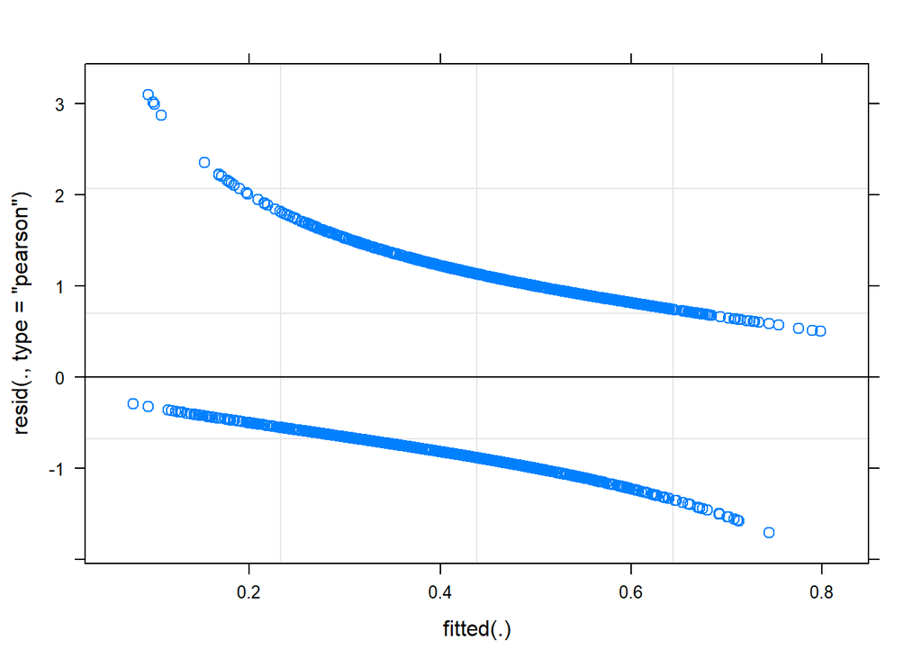

```r
plot(fit_MRP_update)
```

My computer also just about crashed loading in the ACS data - which could mean I was loading in the wrong one from the website, but if I had successfully loaded it, I would have: predicted the model fit above with new data introduced (the ACS data, which would also have the probability), compare the two models and their predictions, and find probabilities by state. I could then find the estimates and order them as asked for.